# examples_0414

Solve the equation below.
$$60=(x+8)\cdot
3$$

Rewrite the given equation.
$$60=(x+8)\cdot 3$$
Divide both sides of the equation by 3.

$$20=x+8$$

Subtract 8 from both sides of the equation.

$$12=x$$

Switch sides (which is allowed because equality is commutative).

$$x=12$$

You can check your possible answer by substituting 12 for $x$ in the original equation.

$$60\stackrel{?}{=}((12)+8)\cdot
3$$

$$60 \stackrel{?}{=} 20\cdot
3$$

$$60 \stackrel{\checkmark}{=}
60$$

So, indeed we see that $x=12$ is a solution to the equation.

Solve the equation below.
$$36=(x-3)\cdot
4$$

Rewrite the given equation.
$$36=(x-3)\cdot 4$$
Divide both sides of the equation by 4.

$$9=x-3$$

Add 3 to both sides of the equation.

$$12=x$$

Switch sides (which is allowed because equality is commutative).

$$x=12$$

You can check your possible answer by substituting 12 for $x$ in the original equation.

$$36\stackrel{?}{=}((12)-3)\cdot
4$$

$$36 \stackrel{?}{=} 9\cdot 4$$

$$36 \stackrel{\checkmark}{=}
36$$

So, indeed we see that $x=12$ is a solution to the equation.

Solve the equation below.
$$18=(x+4)\cdot
2$$

Rewrite the given equation.
$$18=(x+4)\cdot 2$$
Divide both sides of the equation by 2.

$$9=x+4$$

Subtract 4 from both sides of the equation.

$$5=x$$

Switch sides (which is allowed because equality is commutative).

$$x=5$$

You can check your possible answer by substituting 5 for $x$ in the original equation.

$$18\stackrel{?}{=}((5)+4)\cdot
2$$

$$18 \stackrel{?}{=} 9\cdot 2$$

$$18 \stackrel{\checkmark}{=}
18$$

So, indeed we see that $x=5$ is a solution to the equation.

Solve the equation below.
$$39=(x+9)\cdot
3$$

Rewrite the given equation.
$$39=(x+9)\cdot 3$$
Divide both sides of the equation by 3.

$$13=x+9$$

Subtract 9 from both sides of the equation.

$$4=x$$

Switch sides (which is allowed because equality is commutative).

$$x=4$$

You can check your possible answer by substituting 4 for $x$ in the original equation.

$$39\stackrel{?}{=}((4)+9)\cdot
3$$

$$39 \stackrel{?}{=} 13\cdot
3$$

$$39 \stackrel{\checkmark}{=}
39$$

So, indeed we see that $x=4$ is a solution to the equation.

Solve the equation below.
$$2=\frac{x}{2}-4$$

Rewrite the given equation.
$$2=\frac{x}{2}-4$$
Add 4 to both sides of the equation.

$$6=\frac{x}{2}$$

Multiply both sides of the equation by 2.

$$12=x$$

Switch sides (which is allowed because equality is commutative).

$$x=12$$

You can check your possible answer by substituting 12 for $x$ in the original equation.

$$2\stackrel{?}{=}\frac{(12)}{2}-4$$

$$2 \stackrel{?}{=} 6-4$$

$$2 \stackrel{\checkmark}{=}
2$$

So, indeed we see that $x=12$ is a solution to the equation.

A student has taken 4 exams and scored an average of 62.5. What score does the student need on the next exam to bring the average to 65? (All exams are equally weighted in the average.)

Find the current total.
$$4 \cdot 62.5 =
250$$

Find the necessary total.
$$5\cdot65 =
325$$

Find the difference of the totals.
$$325-250 = 75$$

The answer is 75.

A student has taken 3 exams and scored an average of 67. What score does the student need on the next exam to bring the average to 70? (All exams are equally weighted in the average.)

Find the current total.
$$3 \cdot 67 =
201$$

Find the necessary total.
$$4\cdot70 =
280$$

Find the difference of the totals.
$$280-201 = 79$$

The answer is 79.

A student has taken 3 exams and scored an average of 60. What score does the student need on the next exam to bring the average to 65? (All exams are equally weighted in the average.)

Find the current total.
$$3 \cdot 60 =
180$$

Find the necessary total.
$$4\cdot65 =
260$$

Find the difference of the totals.
$$260-180 = 80$$

The answer is 80.

A student has taken 5 exams and scored an average of 64.2. What score does the student need on the next exam to bring the average to 70? (All exams are equally weighted in the average.)

Find the current total.
$$5 \cdot 64.2 =
321$$

Find the necessary total.
$$6\cdot70 =
420$$

Find the difference of the totals.
$$420-321 = 99$$

The answer is 99.

A student has taken 6 exams and scored an average of 71. What score does the student need on the next exam to bring the average to 75? (All exams are equally weighted in the average.)

Find the current total.
$$6 \cdot 71 =
426$$

Find the necessary total.
$$7\cdot75 =
525$$

Find the difference of the totals.
$$525-426 = 99$$

The answer is 99.

An alien creature flies a round trip --- from home, to school, and back home --- using the exact same route both directions (so the distances of the initial and return trips are equal).

On the initial trip, the creature maintains a speed of 41 meters per second. On the return trip, the creature maintains a speed of 36 meters per second.

What was the average speed, in m/s, of the entire trip? (The tolerance is $\pm 0.01$ m/s.)

You might incorrectly guess the average speed for the trip is simply $\frac{41+36}{2}$, but you'd be wrong.

The "easy" way to do this is to pick a distance. You can later check that you'll get the same answer for any distance.

I'll pick a distance of 1000 meters for each trip.

- Time of initial trip = $\frac{1000}{41}=24.3902439$ seconds.
- Time of return trip = $\frac{1000}{36}=27.7777778$ seconds.

The total distance traveled is 2000 meters. The total time is $24.3902439+27.7777778=52.1680217$ seconds. To find the average speed, divide the total distance by the total time.

$$\frac{2000~\mathrm{m}}{52.1680217~\mathrm{s}}~=~38.3376623~~
\mathrm{\frac{m}{s}}$$

Of course, there is a cooler way to do this. Let's use the following variables:

$$\begin{align}
s_1 &= \text{speed to school}\\
s_2 &= \text{speed returning home}\\
D &= \text{distance}\\
t_1 &= \text{time to get to school}\\
t_2 &= \text{time to return home}\\
\bar{s} &= \text{average speed for round trip}
\end{align}$$

We can make some simple statements:

$$\bar{s} = \frac{D}{t_1+t_2}$$
$$t_1 = \frac{D}{s_1}$$
$$t_2 = \frac{D}{s_2}$$

If you combine all three of the above equations, you should be able to make a formula for $\bar{s}$ that only depends on $s_1$ and $s_2$.

An alien creature flies a round trip --- from home, to school, and back home --- using the exact same route both directions (so the distances of the initial and return trips are equal).

On the initial trip, the creature maintains a speed of 81 meters per second. On the return trip, the creature maintains a speed of 74 meters per second.

What was the average speed, in m/s, of the entire trip? (The tolerance is $\pm 0.01$ m/s.)

You might incorrectly guess the average speed for the trip is simply $\frac{81+74}{2}$, but you'd be wrong.

The "easy" way to do this is to pick a distance. You can later check that you'll get the same answer for any distance.

I'll pick a distance of 1000 meters for each trip.

- Time of initial trip = $\frac{1000}{81}=12.345679$ seconds.
- Time of return trip = $\frac{1000}{74}=13.5135135$ seconds.

The total distance traveled is 2000 meters. The total time is $12.345679+13.5135135=25.8591925$ seconds. To find the average speed, divide the total distance by the total time.

$$\frac{2000~\mathrm{m}}{25.8591925~\mathrm{s}}~=~77.3419355~~
\mathrm{\frac{m}{s}}$$

Of course, there is a cooler way to do this. Let's use the following variables:

$$\begin{align}
s_1 &= \text{speed to school}\\
s_2 &= \text{speed returning home}\\
D &= \text{distance}\\
t_1 &= \text{time to get to school}\\
t_2 &= \text{time to return home}\\
\bar{s} &= \text{average speed for round trip}
\end{align}$$

We can make some simple statements:

$$\bar{s} = \frac{D}{t_1+t_2}$$
$$t_1 = \frac{D}{s_1}$$
$$t_2 = \frac{D}{s_2}$$

If you combine all three of the above equations, you should be able to make a formula for $\bar{s}$ that only depends on $s_1$ and $s_2$.

An alien creature flies a round trip --- from home, to school, and back home --- using the exact same route both directions (so the distances of the initial and return trips are equal).

On the initial trip, the creature maintains a speed of 24 meters per second. On the return trip, the creature maintains a speed of 52 meters per second.

What was the average speed, in m/s, of the entire trip? (The tolerance is $\pm 0.01$ m/s.)

You might incorrectly guess the average speed for the trip is simply $\frac{24+52}{2}$, but you'd be wrong.

The "easy" way to do this is to pick a distance. You can later check that you'll get the same answer for any distance.

I'll pick a distance of 1000 meters for each trip.

- Time of initial trip = $\frac{1000}{24}=41.6666667$ seconds.
- Time of return trip = $\frac{1000}{52}=19.2307692$ seconds.

The total distance traveled is 2000 meters. The total time is $41.6666667+19.2307692=60.8974359$ seconds. To find the average speed, divide the total distance by the total time.

$$\frac{2000~\mathrm{m}}{60.8974359~\mathrm{s}}~=~32.8421053~~
\mathrm{\frac{m}{s}}$$

Of course, there is a cooler way to do this. Let's use the following variables:

$$\begin{align}
s_1 &= \text{speed to school}\\
s_2 &= \text{speed returning home}\\
D &= \text{distance}\\
t_1 &= \text{time to get to school}\\
t_2 &= \text{time to return home}\\
\bar{s} &= \text{average speed for round trip}
\end{align}$$

We can make some simple statements:

$$\bar{s} = \frac{D}{t_1+t_2}$$
$$t_1 = \frac{D}{s_1}$$
$$t_2 = \frac{D}{s_2}$$

If you combine all three of the above equations, you should be able to make a formula for $\bar{s}$ that only depends on $s_1$ and $s_2$.

An alien creature flies a round trip --- from home, to school, and back home --- using the exact same route both directions (so the distances of the initial and return trips are equal).

On the initial trip, the creature maintains a speed of 92 meters per second. On the return trip, the creature maintains a speed of 81 meters per second.

What was the average speed, in m/s, of the entire trip? (The tolerance is $\pm 0.01$ m/s.)

You might incorrectly guess the average speed for the trip is simply $\frac{92+81}{2}$, but you'd be wrong.

The "easy" way to do this is to pick a distance. You can later check that you'll get the same answer for any distance.

I'll pick a distance of 1000 meters for each trip.

- Time of initial trip = $\frac{1000}{92}=10.8695652$ seconds.
- Time of return trip = $\frac{1000}{81}=12.345679$ seconds.

The total distance traveled is 2000 meters. The total time is $10.8695652+12.345679=23.2152442$ seconds. To find the average speed, divide the total distance by the total time.

$$\frac{2000~\mathrm{m}}{23.2152442~\mathrm{s}}~=~86.150289~~
\mathrm{\frac{m}{s}}$$

Of course, there is a cooler way to do this. Let's use the following variables:

$$\begin{align}
s_1 &= \text{speed to school}\\
s_2 &= \text{speed returning home}\\
D &= \text{distance}\\
t_1 &= \text{time to get to school}\\
t_2 &= \text{time to return home}\\
\bar{s} &= \text{average speed for round trip}
\end{align}$$

We can make some simple statements:

$$\bar{s} = \frac{D}{t_1+t_2}$$
$$t_1 = \frac{D}{s_1}$$
$$t_2 = \frac{D}{s_2}$$

If you combine all three of the above equations, you should be able to make a formula for $\bar{s}$ that only depends on $s_1$ and $s_2$.

An alien creature flies a round trip --- from home, to school, and back home --- using the exact same route both directions (so the distances of the initial and return trips are equal).

On the initial trip, the creature maintains a speed of 40 meters per second. On the return trip, the creature maintains a speed of 17 meters per second.

What was the average speed, in m/s, of the entire trip? (The tolerance is $\pm 0.01$ m/s.)

You might incorrectly guess the average speed for the trip is simply $\frac{40+17}{2}$, but you'd be wrong.

The "easy" way to do this is to pick a distance. You can later check that you'll get the same answer for any distance.

I'll pick a distance of 1000 meters for each trip.

- Time of initial trip = $\frac{1000}{40}=25$ seconds.
- Time of return trip = $\frac{1000}{17}=58.8235294$ seconds.

The total distance traveled is 2000 meters. The total time is $25+58.8235294=83.8235294$ seconds. To find the average speed, divide the total distance by the total time.

$$\frac{2000~\mathrm{m}}{83.8235294~\mathrm{s}}~=~23.8596491~~
\mathrm{\frac{m}{s}}$$

Of course, there is a cooler way to do this. Let's use the following variables:

$$\begin{align}
s_1 &= \text{speed to school}\\
s_2 &= \text{speed returning home}\\
D &= \text{distance}\\
t_1 &= \text{time to get to school}\\
t_2 &= \text{time to return home}\\
\bar{s} &= \text{average speed for round trip}
\end{align}$$

We can make some simple statements:

$$\bar{s} = \frac{D}{t_1+t_2}$$
$$t_1 = \frac{D}{s_1}$$
$$t_2 = \frac{D}{s_2}$$

If you combine all three of the above equations, you should be able to make a formula for $\bar{s}$ that only depends on $s_1$ and $s_2$.

A [Lagrange polynomial](https://en.wikipedia.org/wiki/Lagrange_polynomial) is a polynomial that exactly hits all points from a list.

Let's say we have three points: $(x_1,y_1)$ and $(x_2,y_2)$ and $(x_3,y_3)$. The Lagrange polynomial is:

$$L(x)~~=~~y_1\cdot\frac{(x-x_2)(x-x_3)}{(x_1-x_2)(x_1-x_3)}~+~y_2\cdot\frac{(x-x_1)(x-x_3)}{(x_2-x_1)(x_2-x_3)}~+~y_3\cdot\frac{(x-x_1)(x-x_2)}{(x_3-x_1)(x_3-x_2)}$$

You can probably guess correctly how this would generalize with more points, but this seems tedious enough. Eh, what the heck... if there were four points, it would look like:

$$L(x)~~=~~y_1\cdot\frac{(x-x_2)(x-x_3)(x-x_4)}{(x_1-x_2)(x_1-x_3)(x_1-x_4)}~+~y_2\cdot\frac{(x-x_1)(x-x_3)(x-x_4)}{(x_2-x_1)(x_2-x_3)(x_2-x_4)}~+~y_3\cdot\frac{(x-x_1)(x-x_2)(x-x_4)}{(x_3-x_1)(x_3-x_2)(x_3-x_4)}~+~y_4\cdot\frac{(x-x_1)(x-x_2)(x-x_3)}{(x_4-x_1)(x_4-x_2)(x_4-x_3)}$$

LOL. Anyway, I want you to find the Lagrange polynomial from the following list of three points.

$$(2,9)$$
$$(3,8)$$
$$(5,7)$$

First define $L(x)$. Then, evaluate $L(6)$. The tolerance is $\pm 0.01$.

Okay, this is a bit tedious, but it's not SO bad. Identify the givens:

$$\begin{align}
x_1 &= 2 &&& y_1 &= 9 \\
x_2 &= 3 &&& y_2 &= 8 \\
x_3 &= 5 &&& y_3 &= 7 \\
\end{align}$$

Plug those values into the Lagrange polynomial for three points. I would type this function (and the three points) into Desmos. Make sure the curve hits all three points!

$$L(x)~~=~~9\cdot\frac{(x-3)(x-5)}{(2-3)(2-5)}~+~8\cdot\frac{(x-2)(x-5)}{(3-2)(3-5)}~+~7\cdot\frac{(x-2)(x-3)}{(5-2)(5-3)}$$

Now, evaluate $L(6)$.
$$L(6)~=~7$$

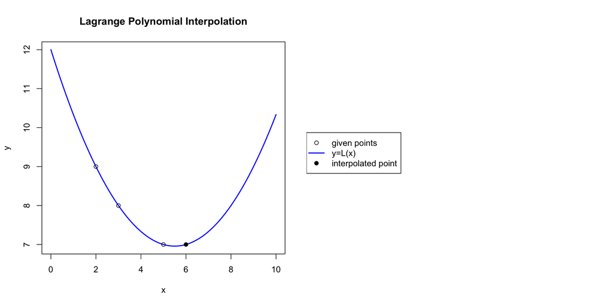

A [Lagrange polynomial](https://en.wikipedia.org/wiki/Lagrange_polynomial) is a polynomial that exactly hits all points from a list.

Let's say we have three points: $(x_1,y_1)$ and $(x_2,y_2)$ and $(x_3,y_3)$. The Lagrange polynomial is:

$$L(x)~~=~~y_1\cdot\frac{(x-x_2)(x-x_3)}{(x_1-x_2)(x_1-x_3)}~+~y_2\cdot\frac{(x-x_1)(x-x_3)}{(x_2-x_1)(x_2-x_3)}~+~y_3\cdot\frac{(x-x_1)(x-x_2)}{(x_3-x_1)(x_3-x_2)}$$

You can probably guess correctly how this would generalize with more points, but this seems tedious enough. Eh, what the heck... if there were four points, it would look like:

$$L(x)~~=~~y_1\cdot\frac{(x-x_2)(x-x_3)(x-x_4)}{(x_1-x_2)(x_1-x_3)(x_1-x_4)}~+~y_2\cdot\frac{(x-x_1)(x-x_3)(x-x_4)}{(x_2-x_1)(x_2-x_3)(x_2-x_4)}~+~y_3\cdot\frac{(x-x_1)(x-x_2)(x-x_4)}{(x_3-x_1)(x_3-x_2)(x_3-x_4)}~+~y_4\cdot\frac{(x-x_1)(x-x_2)(x-x_3)}{(x_4-x_1)(x_4-x_2)(x_4-x_3)}$$

LOL. Anyway, I want you to find the Lagrange polynomial from the following list of three points.

$$(2,7)$$
$$(4,3)$$
$$(8,5)$$

First define $L(x)$. Then, evaluate $L(9)$. The tolerance is $\pm 0.01$.

Okay, this is a bit tedious, but it's not SO bad. Identify the givens:

$$\begin{align}
x_1 &= 2 &&& y_1 &= 7 \\
x_2 &= 4 &&& y_2 &= 3 \\
x_3 &= 8 &&& y_3 &= 5 \\
\end{align}$$

Plug those values into the Lagrange polynomial for three points. I would type this function (and the three points) into Desmos. Make sure the curve hits all three points!

$$L(x)~~=~~7\cdot\frac{(x-4)(x-8)}{(2-4)(2-8)}~+~3\cdot\frac{(x-2)(x-8)}{(4-2)(4-8)}~+~5\cdot\frac{(x-2)(x-4)}{(8-2)(8-4)}$$

Now, evaluate $L(9)$.
$$L(9)~=~7.5833333$$

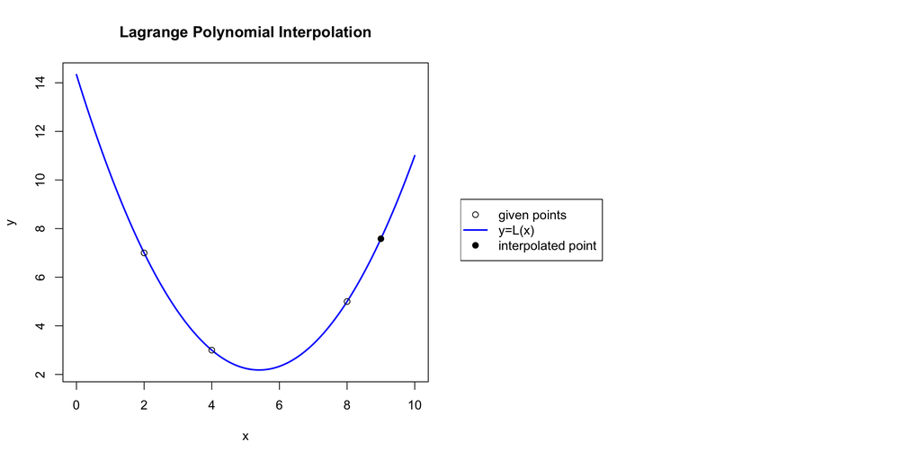

A [Lagrange polynomial](https://en.wikipedia.org/wiki/Lagrange_polynomial) is a polynomial that exactly hits all points from a list.

Let's say we have three points: $(x_1,y_1)$ and $(x_2,y_2)$ and $(x_3,y_3)$. The Lagrange polynomial is:

$$L(x)~~=~~y_1\cdot\frac{(x-x_2)(x-x_3)}{(x_1-x_2)(x_1-x_3)}~+~y_2\cdot\frac{(x-x_1)(x-x_3)}{(x_2-x_1)(x_2-x_3)}~+~y_3\cdot\frac{(x-x_1)(x-x_2)}{(x_3-x_1)(x_3-x_2)}$$

You can probably guess correctly how this would generalize with more points, but this seems tedious enough. Eh, what the heck... if there were four points, it would look like:

$$L(x)~~=~~y_1\cdot\frac{(x-x_2)(x-x_3)(x-x_4)}{(x_1-x_2)(x_1-x_3)(x_1-x_4)}~+~y_2\cdot\frac{(x-x_1)(x-x_3)(x-x_4)}{(x_2-x_1)(x_2-x_3)(x_2-x_4)}~+~y_3\cdot\frac{(x-x_1)(x-x_2)(x-x_4)}{(x_3-x_1)(x_3-x_2)(x_3-x_4)}~+~y_4\cdot\frac{(x-x_1)(x-x_2)(x-x_3)}{(x_4-x_1)(x_4-x_2)(x_4-x_3)}$$

LOL. Anyway, I want you to find the Lagrange polynomial from the following list of three points.

$$(3,7)$$
$$(5,8)$$
$$(6,2)$$

First define $L(x)$. Then, evaluate $L(4)$. The tolerance is $\pm 0.01$.

Okay, this is a bit tedious, but it's not SO bad. Identify the givens:

$$\begin{align}
x_1 &= 3 &&& y_1 &= 7 \\
x_2 &= 5 &&& y_2 &= 8 \\
x_3 &= 6 &&& y_3 &= 2 \\
\end{align}$$

Plug those values into the Lagrange polynomial for three points. I would type this function (and the three points) into Desmos. Make sure the curve hits all three points!

$$L(x)~~=~~7\cdot\frac{(x-5)(x-6)}{(3-5)(3-6)}~+~8\cdot\frac{(x-3)(x-6)}{(5-3)(5-6)}~+~2\cdot\frac{(x-3)(x-5)}{(6-3)(6-5)}$$

Now, evaluate $L(4)$.
$$L(4)~=~9.6666667$$

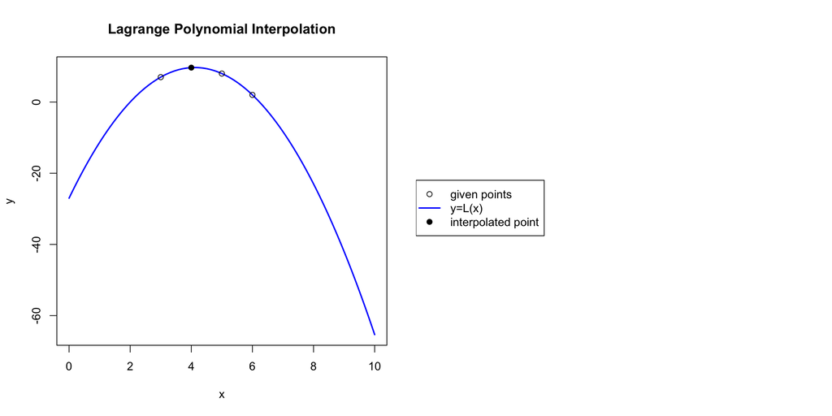

A [Lagrange polynomial](https://en.wikipedia.org/wiki/Lagrange_polynomial) is a polynomial that exactly hits all points from a list.

Let's say we have three points: $(x_1,y_1)$ and $(x_2,y_2)$ and $(x_3,y_3)$. The Lagrange polynomial is:

$$L(x)~~=~~y_1\cdot\frac{(x-x_2)(x-x_3)}{(x_1-x_2)(x_1-x_3)}~+~y_2\cdot\frac{(x-x_1)(x-x_3)}{(x_2-x_1)(x_2-x_3)}~+~y_3\cdot\frac{(x-x_1)(x-x_2)}{(x_3-x_1)(x_3-x_2)}$$

You can probably guess correctly how this would generalize with more points, but this seems tedious enough. Eh, what the heck... if there were four points, it would look like:

$$L(x)~~=~~y_1\cdot\frac{(x-x_2)(x-x_3)(x-x_4)}{(x_1-x_2)(x_1-x_3)(x_1-x_4)}~+~y_2\cdot\frac{(x-x_1)(x-x_3)(x-x_4)}{(x_2-x_1)(x_2-x_3)(x_2-x_4)}~+~y_3\cdot\frac{(x-x_1)(x-x_2)(x-x_4)}{(x_3-x_1)(x_3-x_2)(x_3-x_4)}~+~y_4\cdot\frac{(x-x_1)(x-x_2)(x-x_3)}{(x_4-x_1)(x_4-x_2)(x_4-x_3)}$$

LOL. Anyway, I want you to find the Lagrange polynomial from the following list of three points.

$$(4,3)$$
$$(7,6)$$
$$(8,5)$$

First define $L(x)$. Then, evaluate $L(9)$. The tolerance is $\pm 0.01$.

Okay, this is a bit tedious, but it's not SO bad. Identify the givens:

$$\begin{align}
x_1 &= 4 &&& y_1 &= 3 \\
x_2 &= 7 &&& y_2 &= 6 \\
x_3 &= 8 &&& y_3 &= 5 \\
\end{align}$$

Plug those values into the Lagrange polynomial for three points. I would type this function (and the three points) into Desmos. Make sure the curve hits all three points!

$$L(x)~~=~~3\cdot\frac{(x-7)(x-8)}{(4-7)(4-8)}~+~6\cdot\frac{(x-4)(x-8)}{(7-4)(7-8)}~+~5\cdot\frac{(x-4)(x-7)}{(8-4)(8-7)}$$

Now, evaluate $L(9)$.
$$L(9)~=~3$$

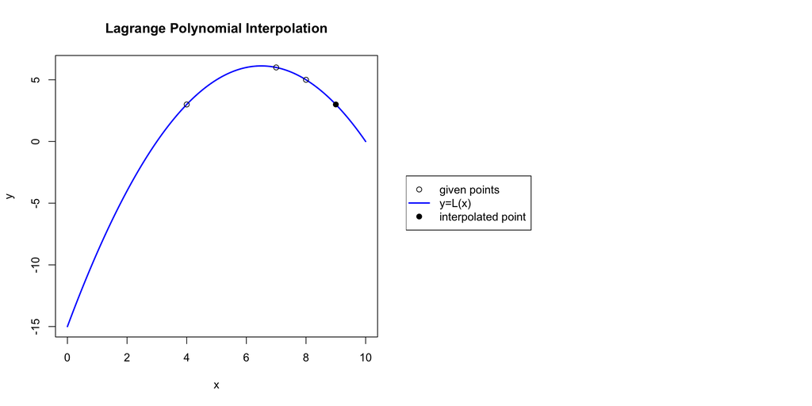

A [Lagrange polynomial](https://en.wikipedia.org/wiki/Lagrange_polynomial) is a polynomial that exactly hits all points from a list.

Let's say we have three points: $(x_1,y_1)$ and $(x_2,y_2)$ and $(x_3,y_3)$. The Lagrange polynomial is:

$$L(x)~~=~~y_1\cdot\frac{(x-x_2)(x-x_3)}{(x_1-x_2)(x_1-x_3)}~+~y_2\cdot\frac{(x-x_1)(x-x_3)}{(x_2-x_1)(x_2-x_3)}~+~y_3\cdot\frac{(x-x_1)(x-x_2)}{(x_3-x_1)(x_3-x_2)}$$

You can probably guess correctly how this would generalize with more points, but this seems tedious enough. Eh, what the heck... if there were four points, it would look like:

$$L(x)~~=~~y_1\cdot\frac{(x-x_2)(x-x_3)(x-x_4)}{(x_1-x_2)(x_1-x_3)(x_1-x_4)}~+~y_2\cdot\frac{(x-x_1)(x-x_3)(x-x_4)}{(x_2-x_1)(x_2-x_3)(x_2-x_4)}~+~y_3\cdot\frac{(x-x_1)(x-x_2)(x-x_4)}{(x_3-x_1)(x_3-x_2)(x_3-x_4)}~+~y_4\cdot\frac{(x-x_1)(x-x_2)(x-x_3)}{(x_4-x_1)(x_4-x_2)(x_4-x_3)}$$

LOL. Anyway, I want you to find the Lagrange polynomial from the following list of three points.

$$(3,2)$$
$$(5,4)$$
$$(7,9)$$

First define $L(x)$. Then, evaluate $L(6)$. The tolerance is $\pm 0.01$.

Okay, this is a bit tedious, but it's not SO bad. Identify the givens:

$$\begin{align}
x_1 &= 3 &&& y_1 &= 2 \\
x_2 &= 5 &&& y_2 &= 4 \\
x_3 &= 7 &&& y_3 &= 9 \\
\end{align}$$

Plug those values into the Lagrange polynomial for three points. I would type this function (and the three points) into Desmos. Make sure the curve hits all three points!

$$L(x)~~=~~2\cdot\frac{(x-5)(x-7)}{(3-5)(3-7)}~+~4\cdot\frac{(x-3)(x-7)}{(5-3)(5-7)}~+~9\cdot\frac{(x-3)(x-5)}{(7-3)(7-5)}$$

Now, evaluate $L(6)$.
$$L(6)~=~6.125$$

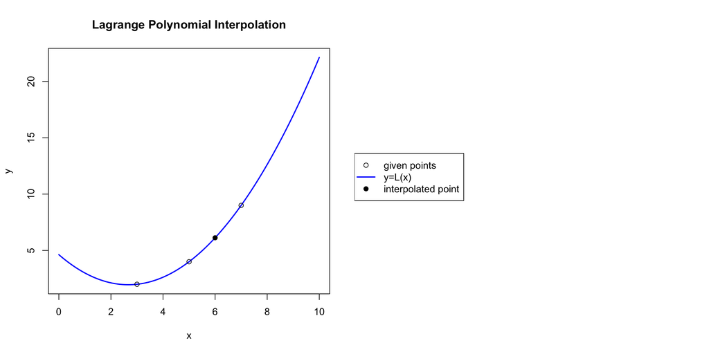

In [Desmos](https://www.desmos.com/calculator), we can get best-fit curves by using their [least-squares regression](https://en.wikipedia.org/wiki/Least_squares) tool. This type of analysis is very important in science and research.

In this problem, I want you to run a cubic regression on the following points:

| x | y |
| --- | --- |
| 1 | 3 |
| 2 | 5 |
| 3 | 5 |
| 4 | 1 |
| 9 | 5 |

The result of the regression will be a cubic polynomial, which we can call $f$. You will then evaluate $f(5)$.

If you copy/paste the above table into a Desmos item, it should create a table. If not, add a new table and add the points shown above.

In that item's top-left corner, there should be a "Add Regression" button; click it. Change the regression type to "Cubic Regression". You'll see a cubic curve that does its best to get as close to the points as possible. You can "Export a snapshot to the expression list" by clicking on the button next to `EQUATION`. In that new expression, replace the $y$ with $f(x)$.

Now, in a new item, you should be able to evaluate $f(5)$. What do you get? (We are using regression to make a prediction. The tolerance is $\pm0.01$.)

Your cubic regression should give the following polynomial.

$$f(x)~=~{0.2494}x^{3}-{3.33}x^{2}+{10.86}x-{4.925}$$

So, $f(5)=-2.6612794$.

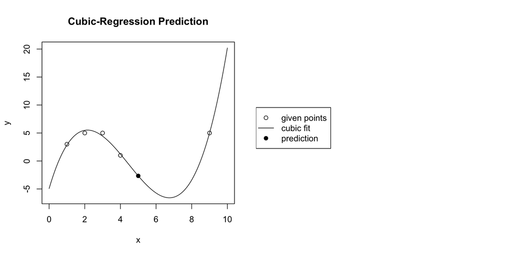

In [Desmos](https://www.desmos.com/calculator), we can get best-fit curves by using their [least-squares regression](https://en.wikipedia.org/wiki/Least_squares) tool. This type of analysis is very important in science and research.

In this problem, I want you to run a cubic regression on the following points:

| x | y |
| --- | --- |
| 1 | 8 |
| 2 | 2 |
| 3 | 2 |
| 6 | 6 |
| 8 | 8 |

The result of the regression will be a cubic polynomial, which we can call $f$. You will then evaluate $f(4)$.

If you copy/paste the above table into a Desmos item, it should create a table. If not, add a new table and add the points shown above.

In that item's top-left corner, there should be a "Add Regression" button; click it. Change the regression type to "Cubic Regression". You'll see a cubic curve that does its best to get as close to the points as possible. You can "Export a snapshot to the expression list" by clicking on the button next to `EQUATION`. In that new expression, replace the $y$ with $f(x)$.

Now, in a new item, you should be able to evaluate $f(4)$. What do you get? (We are using regression to make a prediction. The tolerance is $\pm0.01$.)

Your cubic regression should give the following polynomial.

$$f(x)~=~{-0.1593}x^{3}+{2.56}x^{2}-{11.37}x+{16.67}$$

So, $f(4)=1.9416138$.

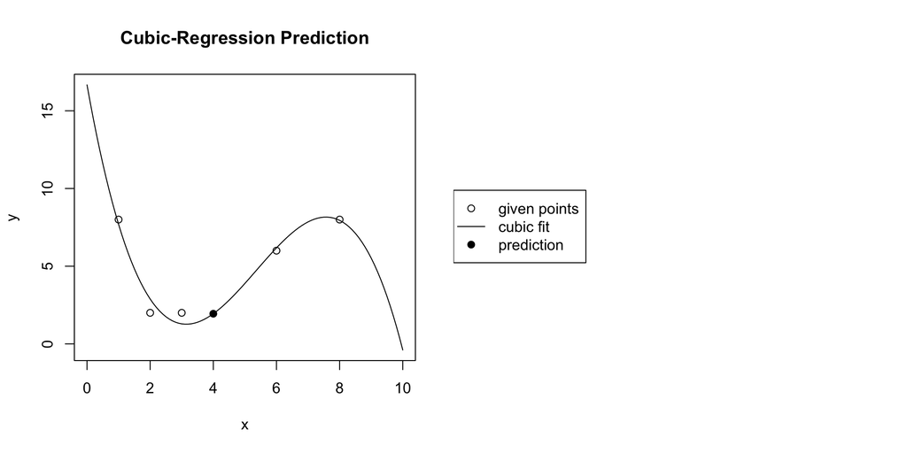

In [Desmos](https://www.desmos.com/calculator), we can get best-fit curves by using their [least-squares regression](https://en.wikipedia.org/wiki/Least_squares) tool. This type of analysis is very important in science and research.

In this problem, I want you to run a cubic regression on the following points:

| x | y |
| --- | --- |
| 1 | 2 |
| 2 | 4 |
| 3 | 6 |
| 5 | 4 |
| 9 | 2 |

The result of the regression will be a cubic polynomial, which we can call $f$. You will then evaluate $f(4)$.

If you copy/paste the above table into a Desmos item, it should create a table. If not, add a new table and add the points shown above.

In that item's top-left corner, there should be a "Add Regression" button; click it. Change the regression type to "Cubic Regression". You'll see a cubic curve that does its best to get as close to the points as possible. You can "Export a snapshot to the expression list" by clicking on the button next to `EQUATION`. In that new expression, replace the $y$ with $f(x)$.

Now, in a new item, you should be able to evaluate $f(4)$. What do you get? (We are using regression to make a prediction. The tolerance is $\pm0.01$.)

Your cubic regression should give the following polynomial.

$$f(x)~=~{0.08302}x^{3}-{1.384}x^{2}+{6.305}x-{3.185}$$

So, $f(4)=5.2060991$.

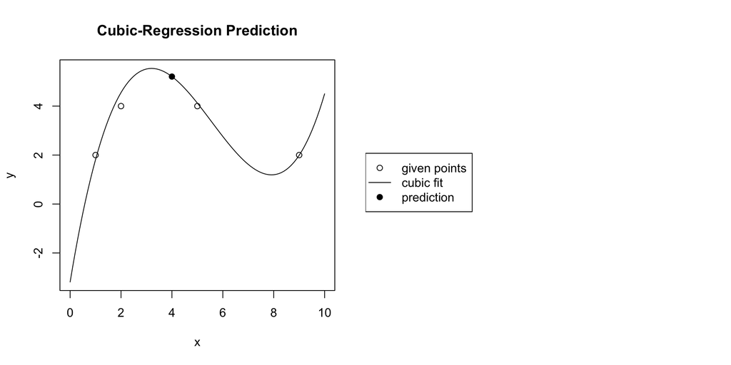

In [Desmos](https://www.desmos.com/calculator), we can get best-fit curves by using their [least-squares regression](https://en.wikipedia.org/wiki/Least_squares) tool. This type of analysis is very important in science and research.

In this problem, I want you to run a cubic regression on the following points:

| x | y |
| --- | --- |
| 1 | 8 |
| 5 | 7 |
| 6 | 7 |
| 8 | 7 |
| 9 | 5 |

The result of the regression will be a cubic polynomial, which we can call $f$. You will then evaluate $f(7)$.

If you copy/paste the above table into a Desmos item, it should create a table. If not, add a new table and add the points shown above.

In that item's top-left corner, there should be a "Add Regression" button; click it. Change the regression type to "Cubic Regression". You'll see a cubic curve that does its best to get as close to the points as possible. You can "Export a snapshot to the expression list" by clicking on the button next to `EQUATION`. In that new expression, replace the $y$ with $f(x)$.

Now, in a new item, you should be able to evaluate $f(7)$. What do you get? (We are using regression to make a prediction. The tolerance is $\pm0.01$.)

Your cubic regression should give the following polynomial.

$$f(x)~=~{-0.0578}x^{3}+{0.8506}x^{2}-{3.61}x+{10.83}$$

So, $f(7)=7.4059135$.

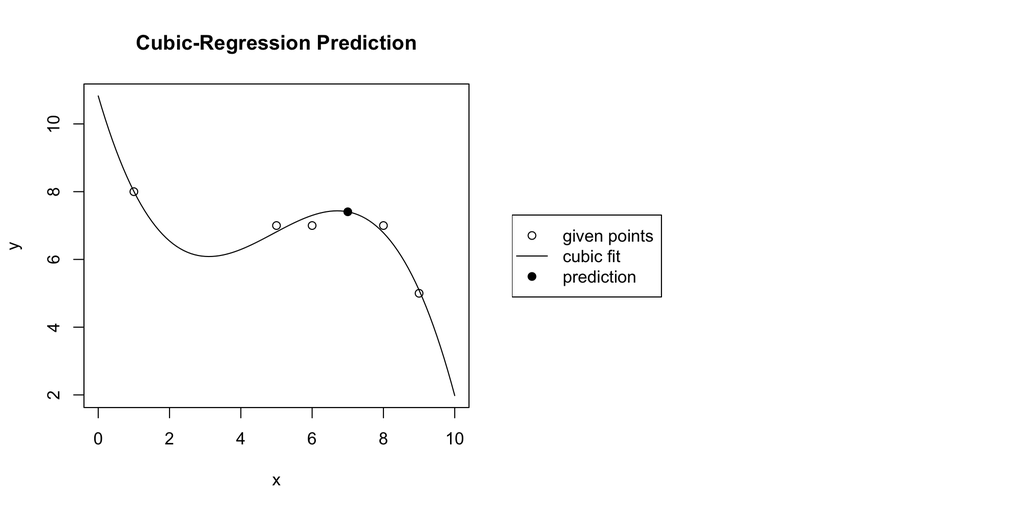

In [Desmos](https://www.desmos.com/calculator), we can get best-fit curves by using their [least-squares regression](https://en.wikipedia.org/wiki/Least_squares) tool. This type of analysis is very important in science and research.

In this problem, I want you to run a cubic regression on the following points:

| x | y |
| --- | --- |
| 3 | 6 |
| 4 | 3 |
| 5 | 2 |
| 7 | 4 |
| 8 | 1 |

The result of the regression will be a cubic polynomial, which we can call $f$. You will then evaluate $f(1)$.

If you copy/paste the above table into a Desmos item, it should create a table. If not, add a new table and add the points shown above.

In that item's top-left corner, there should be a "Add Regression" button; click it. Change the regression type to "Cubic Regression". You'll see a cubic curve that does its best to get as close to the points as possible. You can "Export a snapshot to the expression list" by clicking on the button next to `EQUATION`. In that new expression, replace the $y$ with $f(x)$.

Now, in a new item, you should be able to evaluate $f(1)$. What do you get? (We are using regression to make a prediction. The tolerance is $\pm0.01$.)

Your cubic regression should give the following polynomial.

$$f(x)~=~{-0.3529}x^{3}+{5.929}x^{2}-{31.99}x+{58.26}$$

So, $f(1)=31.8487395$.

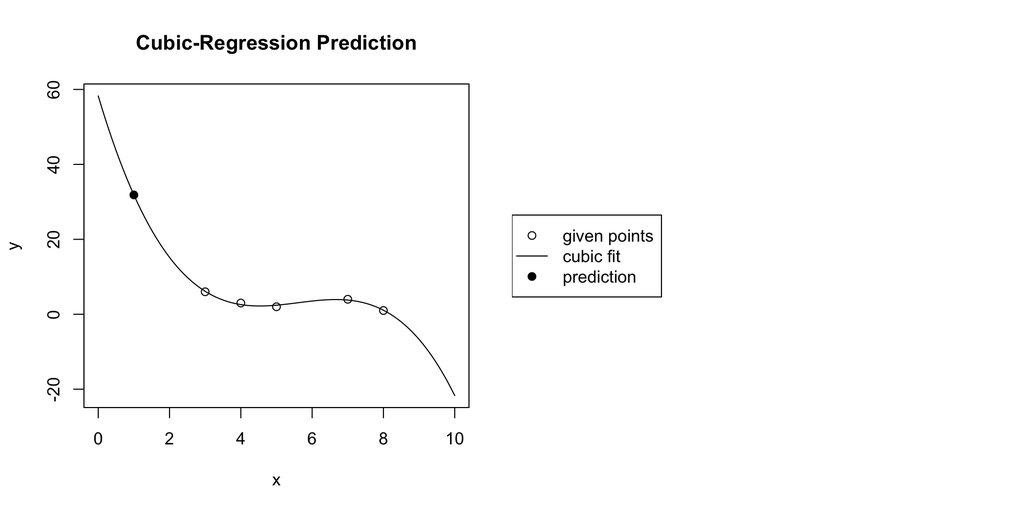